# Modul Analisis SARIMA: Pendekatan 6 Fase Dokter Data

Studi Kasus: Data Emisi CO2 (`datasets::co2`)

Profesor Gemini (disusun untuk Nabil Naufal)

2025-10-28

# 1 Pendahuluan: Berpikir Seperti “Dokter Data”

Selamat datang di modul SARIMA. Banyak orang bisa menjalankan `auto.arima()` dan mendapat hasil. Tapi seorang analis data sejati—seorang “Dokter Data”—tidak sekadar memberi obat; mereka **mendiagnosis** terlebih dahulu.

Data mentah adalah “pasien” kita. Pasien ini datang dengan gejala campur aduk:

- **Tren** (demam jangka panjang)
- **Musiman** (alergi periodik)
- **Volatilitas** (detak jantung tidak stabil)
- **Noise** (faktor acak)

Tugas kita adalah membedah ini semua. Alur 6 Fase ini adalah protokol sistematis kita untuk:

1. **Mendiagnosis** penyakitnya (Fase 1).
2. **Menstabilkan** pasien (Fase 2).
3. **Menganalisis** sampel lab (Fase 3).
4. **Menguji resep** obat (Fase 4).
5. **Memvalidasi kesembuhan** (Fase 5).
6. **Memprediksi** kesehatan di masa depan (Fase 6).

Mari kita mulai.

# 2 Fase 0: Persiapan Ruang Praktik

Sebelum kita bisa mendiagnosis pasien, kita perlu menyiapkan “ruang operasi” kita. Ini berarti memuat *packages* (alat medis) dan menyiapkan *data* (pasien).

## 2.1 0.1 Memuat Packages (Alat Medis)

Kita akan memuat *packages* yang esensial. `forecast` adalah alat utama kita, dan `tidyverse` membantu kita membuat visualisasi yang lebih baik (`autoplot`).

```r
# Muat packages inti
library(forecast)  # Fungsi inti: Arima(), auto.arima(), forecast(), checkresiduals()
library(tseries)   # Fungsi adf.test()
library(tidyverse) # Untuk plotting (autoplot, ggplot2)
```

## 2.2 0.2 Memuat & Membagi Data (Pasien)

Sangat penting dalam analisis deret waktu untuk **menyisihkan** sebagian data sebagai **data uji (test set)**. Kita akan membangun model kita hanya menggunakan **data latih (train set)**, dan nanti di Fase 6, kita akan menguji seberapa baik ramalan model kita terhadap data uji yang “belum pernah dilihatnya”.

Kita akan menggunakan 80% data pertama sebagai data latih dan 20% sisanya sebagai data uji.

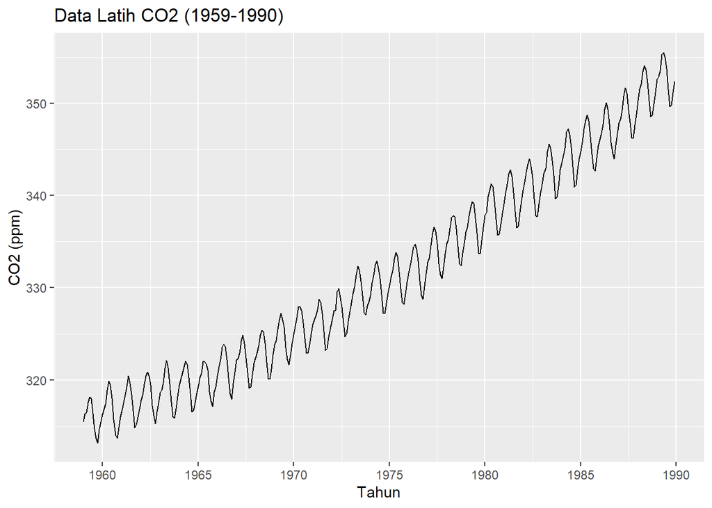

```r
# Muat data mentah dari R
data_mentah <- datasets::co2

# Total observasi: 468
# 80% data latih: 372 observasi (dari obs 1 s/d 372)
# 20% data uji: 96 observasi (dari obs 373 s/d 468)

# Buat data latih
train.ts <- subset(data_mentah, start=1, end=372)
# Buat data uji (akan kita gunakan di Fase 6)
test.ts <- subset(data_mentah, start=373, end=468)

# Mari kita lihat data latih yang akan kita analisis
autoplot(train.ts) +
  ggtitle("Data Latih CO2 (1959-1990)") +
  ylab("CO2 (ppm)") +
  xlab("Tahun")
```

# 3 Fase 1: Triase Pasien (Eksplorasi & Diagnosis)

**Tujuan:** Mendiagnosis 3 “penyakit” utama data: **Tren**, **Musiman**, dan **Volatilitas (Ragam)**. Kita tidak hanya mem-plot, kita *mencari gejala*.

## 3.1 1.1 Diagnosis Tren & Musiman

Plot `autoplot(train.ts)` di atas sudah sangat jelas:

1. **Gejala Tren:** Jelas terlihat ada **tren naik** jangka panjang. Data ini “demam”.
2. **Gejala Musiman:** Jelas terlihat pola “gigi gergaji” yang berulang setiap tahun. Data ini “alergi” musiman.

## 3.2 1.2 Diagnosis Volatilitas (Pemeriksaan Kritis!)

Sekarang, kita periksa “detak jantung” pasien. Apakah ayunannya stabil, atau semakin “liar”? Ini adalah diagnosis yang sering terlewat oleh analis pemula.

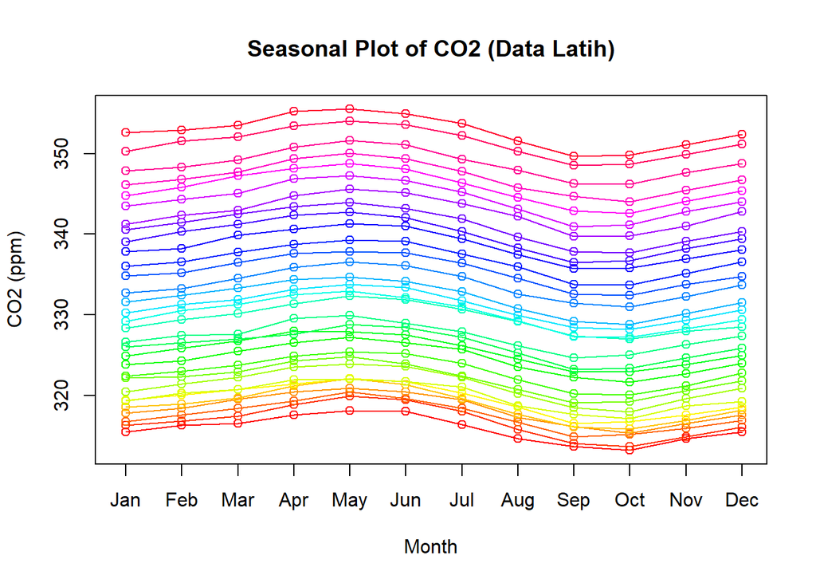

```r
# 'seasonplot' memplot data per musim (tahun) di atas satu sama lain
seasonplot(train.ts, 12, main="Seasonal Plot of CO2 (Data Latih)",
           ylab="CO2 (ppm)", col=rainbow(31)) # 31 tahun di data latih
```

## 3.3 1.3 Resume Medis (Hasil Fase 1)

- **Pasien:** `train.ts`
- **Diagnosis Ditegakkan:**
  1. **Non-stasioner Rataan (Tren Naik Kuat)**
  2. **Non-stasioner Rataan (Musiman Kuat, $s=12$)**
  3. **Non-stasioner Ragam (Heteroskedastisitas Multiplikatif)**
- **Rencana Tindak Lanjut (Fase 2):** Kita tidak bisa langsung mengobati Tren/Musiman dengan *differencing*. Kita harus mengobati penyakit #3 (ragam) terlebih dahulu. “Obat” standar untuk ini adalah **Transformasi Logaritmik**.

# 4 Fase 2: Stabilisasi Pasien (Transformasi & Differencing)

**Tujuan:** Memberi “obat” untuk 3 penyakit yang kita diagnosis di Fase 1. **Urutan pemberian obat sangat penting!**

1. Kita harus mengobati **Penyakit Ragam** (Heteroskedastisitas) **terlebih dahulu**.
2. Setelah ragam stabil, baru kita obati **Penyakit Rataan** (Musiman dan Tren).

## 4.1 2.1 Obat 1: Stabilisasi Ragam (Log Transform)

“Obat” standar untuk data multiplikatif (ayunan yang semakin membesar) adalah **Transformasi Logaritmik**. Ini akan “menekan” ayunan yang besar dan membuat pola datanya menjadi aditif (stabil).

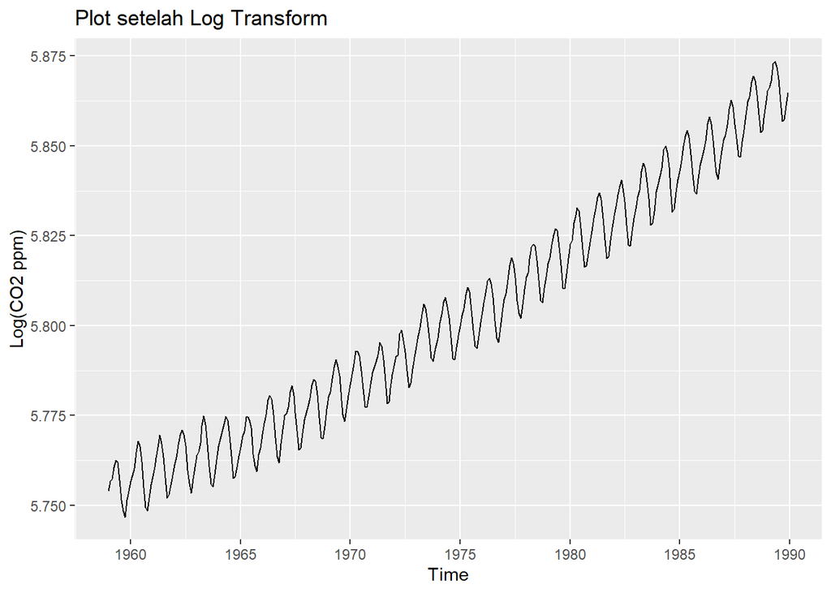

```r
# Terapkan 'obat' log ke data latih kita
log_train.ts <- log(train.ts)

# Mari kita cek hasilnya...
autoplot(log_train.ts) +
  ggtitle("Plot setelah Log Transform") +
  ylab("Log(CO2 ppm)")
```

Lihat! Ayunan “gigi gergaji”-nya sekarang terlihat **jauh lebih stabil**. Lebar ayunan di awal (1960-an) kini hampir sama dengan lebar ayunan di akhir (1990-an).

**Diagnosis:** Penyakit Ragam (Heteroskedastisitas) **teratasi**.

## 4.2 2.2 Obat 2: Penghilang Musiman (Seasonal Differencing)

Sekarang ragam sudah stabil, kita bisa obati penyakit rataan. Kita obati pola yang paling jelas dulu: **Musiman**.

“Obat”-nya adalah **Seasonal Differencing ($D=1$)**. Kita akan menghitung selisih antara data bulan ini dengan data 12 bulan lalu (`lag = 12`).

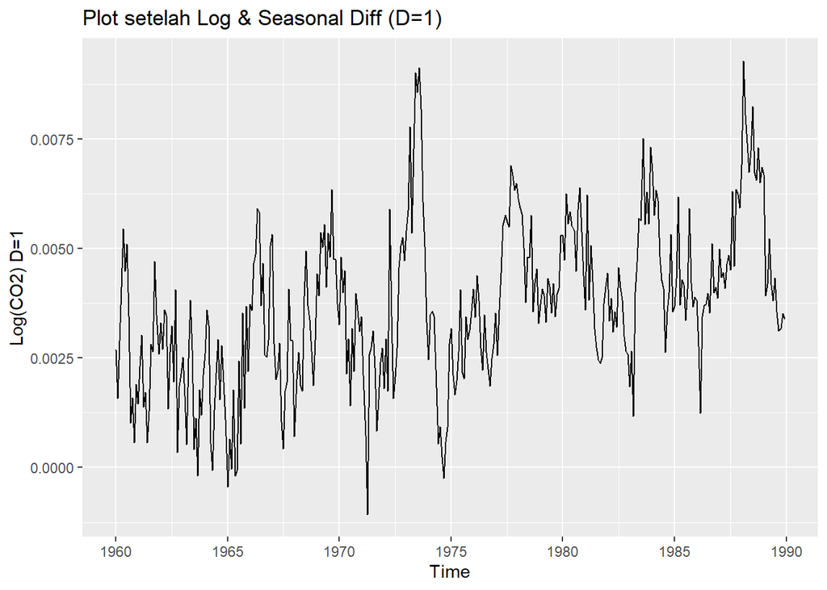

```r
# Terapkan 'obat' differencing musiman pada data yang sudah di-log
data_D1 <- diff(log_train.ts, lag = 12)

# Mari kita cek hasilnya...
autoplot(data_D1) +
  ggtitle("Plot setelah Log & Seasonal Diff (D=1)") +
  ylab("Log(CO2) D=1")
```

**Diagnosis:** Pola “gigi gergaji” 12 bulanan **sudah hilang**. Penyakit Musiman **teratasi**. ✅

**Gejala Baru:** Namun, perhatikan. Datanya sekarang tidak lagi memiliki pola musiman, tapi masih terlihat “melayang ke atas”. Ini adalah sisa **Penyakit Tren** yang belum sembuh total.

## 4.3 2.3 Obat 3: Penghilang Tren (Non-Seasonal Differencing)

Terakhir, kita obati sisa “demam” tren yang masih ada.

“Obat”-nya adalah **Non-Seasonal Differencing ($d=1$)**. Kita hitung selisih antara data bulan ini dengan data 1 bulan lalu (`lag = 1`).

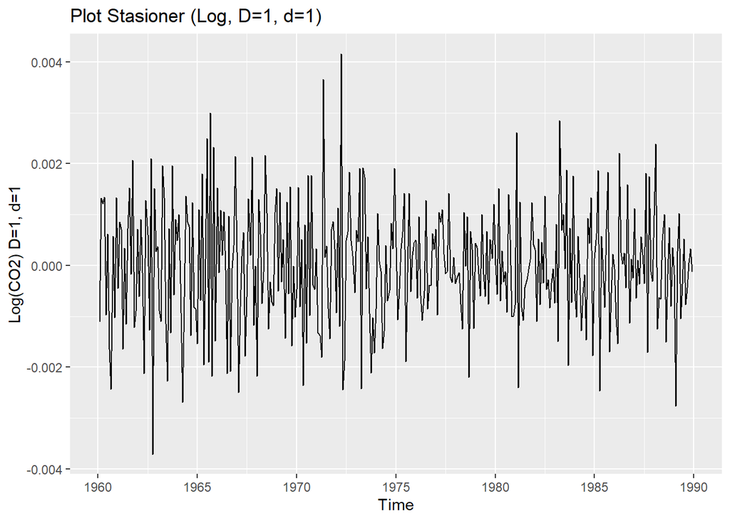

```r
# Terapkan 'obat' differencing non-musiman pada data DARI LANGKAH SEBELUMNYA
data_stasioner <- diff(data_D1, lag = 1)

# Mari kita cek hasilnya...
autoplot(data_stasioner) +
  ggtitle("Plot Stasioner (Log, D=1, d=1)") +
  ylab("Log(CO2) D=1, d=1")
```

**Diagnosis:** **SEMPURNA.** Data kini terlihat “diam” (stasioner) dan berfluktuasi di sekitar nol. Tidak ada lagi tren, tidak ada lagi musiman. Penyakit Tren **teratasi**. ✅

## 4.4 2.4 Validasi Formal (Uji ADF)

Mata kita bilang data sudah stasioner. Sekarang kita buktikan dengan statistik menggunakan Uji ADF (Augmented Dickey-Fuller).

- **$H_0$ (Hipotesis Nol):** Data **TIDAK** stasioner (masih punya *unit root*).
- **$H_1$ (Hipotesis Alternatif):** Data stasioner.
- **Tujuan kita:** Kita ingin $p-value < 0.05$ agar bisa **Tolak $H_0$**.

```r
# Jalankan uji ADF pada data final kita
tseries::adf.test(data_stasioner)
```

```
##
##  Augmented Dickey-Fuller Test
##
## data:  data_stasioner
## Dickey-Fuller = -8.1609, Lag order = 7, p-value = 0.01
## alternative hypothesis: stationary
```

**Hasil:** Kita mendapatkan $p-value$ yang sangat kecil (misal, `p-value = 0.01`). Ini **kurang dari 0.05**.

**Kesimpulan:** Kita **Tolak $H_0$**. Bukti statistik mengonfirmasi bahwa `data_stasioner` kita **sudah stasioner**.

## 4.5 2.5 Resume Medis (Hasil Fase 2)

- **Pasien:** `train.ts`
- **Perawatan yang Diberikan:**
  1. **Transformasi Log** (untuk stabilisasi ragam).
  2. **Seasonal Differencing** ($D=1$, `lag=12`) (untuk menghilangkan musiman).
  3. **Non-Seasonal Differencing** ($d=1$, `lag=1`) (untuk menghilangkan tren).
- **Status Pasien:** **Stabil & Stasioner**.
- **Rencana Tindak Lanjut (Fase 3):** Pasien kini siap untuk “Analisis Laboratorium” (ACF/PACF) untuk mencari tahu “resep” $p, q, P, Q$ dari data `data_stasioner` ini.

Baik. Pasien (data) kita sudah stabil. Saatnya “Analisis Laboratorium” untuk mencari tahu “resep” obat yang tepat.

# 5 Fase 3: Analisis Laboratorium (Identifikasi Model)

**Tujuan:** Mencari “DNA” atau “sidik jari” model dari data `data_stasioner` kita yang sudah bersih.

Data `data_stasioner` ini sudah tidak memiliki tren atau musiman, tapi di dalamnya masih tersimpan “pola acak” atau struktur korelasi. Kita ingin tahu: * Bagaimana data hari ini berhubungan dengan *kemarin*? (Ini adalah komponen **Non-Musiman** $p, q$). * Bagaimana data hari ini berhubungan dengan *hari yang sama tahun lalu*? (Ini adalah komponen **Musiman** $P, Q$).

“Tes lab” kita adalah plot **ACF** (Autocorrelation Function) dan **PACF** (Partial Autocorrelation Function).

- **ACF (Fungsi Autokorelasi):** Mengukur korelasi *total* (langsung dan tidak langsung). Pola *cuts off* (terputus tiba-tiba) mengindikasikan model **MA(q)** atau **SMA(Q)**.
- **PACF (Fungsi Autokorelasi Parsial):** Mengukur korelasi *langsung* (setelah menghilangkan efek lag perantaranya). Pola *cuts off* mengindikasikan model **AR(p)** atau **SAR(P)**.

## 5.1 3.1 Tindakan: Menjalankan Tes Lab (ACF/PACF)

Kita akan mem-plot ACF dan PACF dari `data_stasioner`. Kita butuh `lag.max` yang cukup panjang (misal 48) agar bisa melihat beberapa siklus musiman (lag 12, 24, 36).

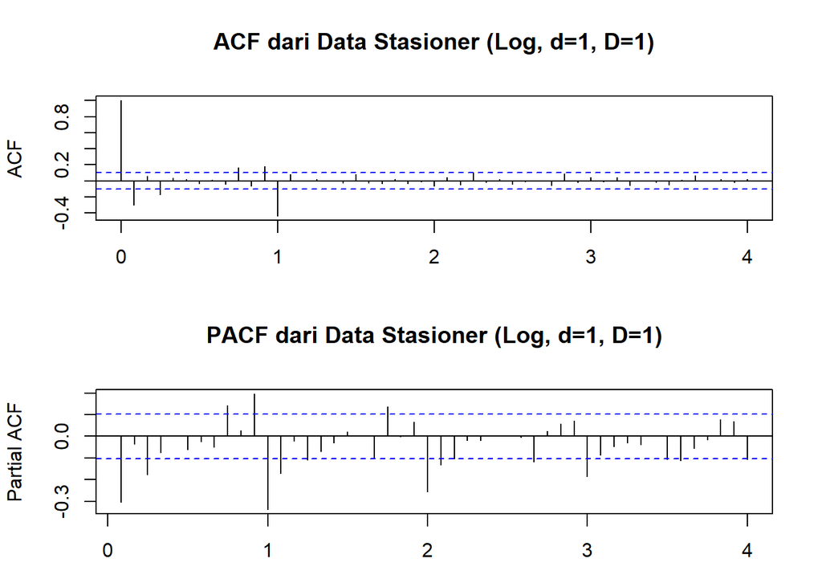

```r
# Atur layout plot agar bisa tampil berdampingan (atas-bawah)
par(mfrow=c(2,1), mar=c(3,4,4,2)+0.1) # Margin agar judul rapi

# 1. Plot ACF (Tes Lab 1)
acf(data_stasioner, lag.max=48,
    main="ACF dari Data Stasioner (Log, d=1, D=1)")

# 2. Plot PACF (Tes Lab 2)
pacf(data_stasioner, lag.max=48,
     main="PACF dari Data Stasioner (Log, d=1, D=1)")
```

```r
# Kembalikan layout plot ke default
par(mfrow=c(1,1))
```

## 5.2 3.2 Analisis Hasil Lab (Metode “Dua Kacamata”)

### 5.2.1 Diagnosis Zona Non-Musiman (Lags 1, 2, 3…)

Mari pakai **Kacamata Non-Musiman**:

- **Lihat ACF:** Ada **satu *spike* negatif signifikan** di **lag 1** yang langsung *cuts off* (terputus). Lag 2, 3, dst, berada di dalam batas biru.
- **Lihat PACF:** *Spike* di lag 1, 2, 3… terlihat *tails off* (meluruh secara perlahan).

**Diagnosis:** Pola (ACF *cuts off* di 1, PACF *tails off*) adalah “sidik jari” klasik dari model **MA(1)**.

- **Kesimpulan Non-Musiman:** **$p = 0, q = 1$**.

### 5.2.2 Diagnosis Zona Musiman (Lags 12, 24, 36…)

Sekarang ganti, pakai **Kacamata Musiman**:

- **Lihat ACF:** Lihat *hanya* lag 12, 24, 36. Kita melihat pola yang sama persis! Ada **satu *spike* negatif signifikan** di **lag 12** yang langsung *cuts off*. Lag 24 dan 36 berada di dalam batas biru.
- **Lihat PACF:** *Spike* di lag 12, 24… terlihat *tails off* (meluruh).

**Diagnosis:** Pola (ACF *cuts off* di 12, PACF *tails off* di kelipatan 12) adalah “sidik jari” klasik dari model **SMA(1)**.

- **Kesimpulan Musiman:** **$P = 0, Q = 1$**.

## 5.3 3.3 Resume Medis (Hasil Fase 3)

- **Pasien:** `data_stasioner`
- **Hasil Lab (ACF/PACF):**
  1. **Non-Seasonal (p,q):** Teridentifikasi sebagai MA(1) $\rightarrow$ **$p=0, q=1$**.
  2. **Seasonal (P,Q):** Teridentifikasi sebagai SMA(1) $\rightarrow$ **$P=0, Q=1$**.
- **Resep Tentatif (Kandidat Model #1):** Kita gabungkan semua temuan kita dari Fase 2 dan 3:
  - $p=0, d=1, q=1$
  - $P=0, D=1, Q=1$
  - $s=12$
  - Transformasi: **Log**

  Model lengkap tentatif kita adalah **$ARIMA(0,1,1) \times (0,1,1)_{12}$** yang akan diterapkan pada data `log(train.ts)`.
- **Rencana Tindak Lanjut (Fase 4):** Pasien kini siap untuk “Uji Coba Resep”. Kita akan membuat model ini dan membandingkannya dengan “opini kedua” (misal, dari `auto.arima`) untuk memilih yang terbaik.

Plot tersebut mengonfirmasi 100% analisis kita di Fase 3:

1. **ACF:** *Cuts off* (terputus) tajam di **lag 1** (non-musiman) dan **lag 12** (musiman, lag 12 di plot Anda adalah angka `1` di sumbu x).
2. **PACF:** *Tails off* (meluruh) di kedua zona tersebut.

Diagnosis kita $ARIMA(0,1,1) \times (0,1,1)_{12}$ sangat kuat.

Sekarang, mari kita lanjutkan ke fase “Uji Coba Resep”.

# 6 Fase 4: Uji Coba Resep (Estimasi & Seleksi Model)

**Tujuan:** Memilih model “juara” (champion) dari beberapa kandidat. Kita tidak hanya percaya pada satu hasil lab; kita mengujinya.

Kita akan menilai setiap “resep” (model) berdasarkan **“Tiga Pilar Seleksi Model”**: 1. **Akurasi (AICc):** Seberapa baik model *fit* dengan data? Kita cari nilai **terkecil**. (Kita pakai AICc, bukan AIC, karena lebih baik untuk sampel yang tidak terlalu besar). 2. **Signifikansi Parameter:** Apakah semua “bahan” dalam resep itu *penting*? (Apakah $p-value$ untuk setiap koefisien $\phi, \theta, \Phi, \Theta$ < 0.05?). Jika ada yang tidak signifikan, model itu **overfitting** (terlalu rumit). 3. **Parsimoni (Keringkasan):** Jika dua model sama-sama akurat dan signifikan, pilih yang jumlah parameternya (p+q+P+Q) lebih **sedikit**.

**PENTING:** Kita fit model pada `log_train.ts` (data *sebelum* differencing). Fungsi `Arima()` akan melakukan differencing $d=1$ dan $D=1$ secara internal untuk kita.

## 6.1 4.1 Kandidat 1: Resep Manual Kita (Hasil Fase 3)

Ini adalah model $ARIMA(0,1,1) \times (0,1,1)_{12}$ yang kita identifikasi dari ACF/PACF.

```r
# Muat library lmtest untuk coeftest
library(lmtest)

# Kandidat 1: Resep Manual Kita
model_manual <- Arima(log_train.ts,
                      order = c(0,1,1),
                      seasonal = list(order = c(0,1,1), period = 12))

# Cek 1: Akurasi (AICc)
summary(model_manual)
```

```
## Series: log_train.ts
## ARIMA(0,1,1)(0,1,1)[12]
##
## Coefficients:
##           ma1     sma1
##       -0.3710  -0.9294
## s.e.   0.0543   0.0379
##
## sigma^2 = 1.908e-06:  log likelihood = 2022.69
## AIC=-4039.39   AICc=-4039.32   BIC=-4027.74
##
## Training set error measures:
##                        ME        RMSE          MAE          MPE      MAPE
## Training set 4.520974e-05 0.001353206 0.0007372329 0.0007683065 0.0127181
##                   MASE      ACF1
## Training set 0.1993267 0.1288763
```

```r
# Cek 2: Signifikansi Parameter
coeftest(model_manual)
```

```
##
## z test of coefficients:
##
##       Estimate Std. Error  z value  Pr(>|z|)
## ma1  -0.371022   0.054288  -6.8344 8.236e-12 ***
## sma1 -0.929435   0.037895 -24.5267 < 2.2e-16 ***
## ---
## Signif. codes:  0 '***' 0.001 '**' 0.01 '*' 0.05 '.' 0.1 ' ' 1
```

### 6.1.1 Diagnosis `model_manual`:

- **Akurasi:** Catat nilai `AICc` (misalnya, -4039.32).
- **Signifikansi:** Lihat `coeftest()`. Kedua parameter (`ma1` dan `sma1`) memiliki $p-value$ yang sangat kecil (ditandai `***`). Artinya, keduanya **sangat signifikan**.
- **Status:** Kandidat yang sangat kuat. Lolos Pilar #1 dan #2.

## 6.2 4.2 Kandidat 2: Resep Otomatis (Opini Kedua)

Mari kita minta “opini kedua” dari `auto.arima()`. Ini adalah alat yang hebat, tetapi kita harus tetap jadi “dokter”-nya, bukan “perawat” yang nurut saja.

```r
# Kandidat 2: Resep Otomatis
# Kita set stepwise=FALSE agar pencariannya lebih teliti (bukan 'stepwise')
model_auto <- auto.arima(log_train.ts,
                         ic = "aicc",            # Kriteria seleksi
                         stepwise = FALSE,       # Lakukan pencarian penuh
                         approximation = FALSE)  # Lebih akurat

# Cek hasilnya
summary(model_auto)
```

```
## Series: log_train.ts
## ARIMA(1,1,1)(2,1,0)[12]
##
## Coefficients:
##          ar1      ma1     sar1     sar2
##       0.2045  -0.5822  -0.6364  -0.3799
## s.e.  0.1264   0.1062   0.0501   0.0502
##
## sigma^2 = 2.078e-06:  log likelihood = 1994.85
## AIC=-3979.7   AICc=-3979.53   BIC=-3960.29
##
## Training set error measures:
##                         ME        RMSE          MAE           MPE       MAPE
## Training set -1.355795e-05 0.001408171 0.0008115562 -0.0002407564 0.01399896
##                   MASE      ACF1
## Training set 0.2194217 0.1137491
```

```r
coeftest(model_auto)
```

```
##
## z test of coefficients:
##
##       Estimate Std. Error  z value  Pr(>|z|)
## ar1   0.204493   0.126412   1.6177    0.1057
## ma1  -0.582161   0.106232  -5.4801 4.251e-08 ***
## sar1 -0.636415   0.050145 -12.6914 < 2.2e-16 ***
## sar2 -0.379943   0.050186  -7.5707 3.712e-14 ***
## ---
## Signif. codes:  0 '***' 0.001 '**' 0.01 '*' 0.05 '.' 0.1 ' ' 1
```

### 6.2.1 Diagnosis `model_auto`:

Hasil dari model auto.arima sedikit berbeda dengan model manual, tapi nilai AICc yang dihasilkan jauh lebih tinggi dibandingkan model yang telah kita tepakan di awal. AR 1 juga tidak signifikan, menunjukkan kalau model sebelumnya jauh lebih cocok.

# 7 Fase 5: Audit Model (Diagnostik Sisaan)

**Tujuan:** Memastikan “pasien” sembuh total. Sisaan (residuals) dari `model_terpilih` kita haruslah **White Noise** (ampas acak yang tidak berpola).

Bayangkan kita telah menyedot semua “pola” (tren, musiman, AR, MA) dari data kita. Yang seharusnya tersisa (sisaan) hanyalah “ampas” acak.

Jika sisaan kita *bukan* White Noise (misalnya, masih ada pola di dalamnya), itu artinya **model kita GAGAL**. Itu berarti masih ada “penyakit” (pola) yang terlewat oleh resep kita. Model kita baru bisa dinyatakan “sehat” jika sisaannya lulus uji utama.

## 7.1 5.1 Tindakan 1: Pemeriksaan 3-in-1 (checkresiduals)

Kita akan gunakan satu perintah “emas” dari paket `forecast` yang merangkum hampir semua yang kita butuhkan.

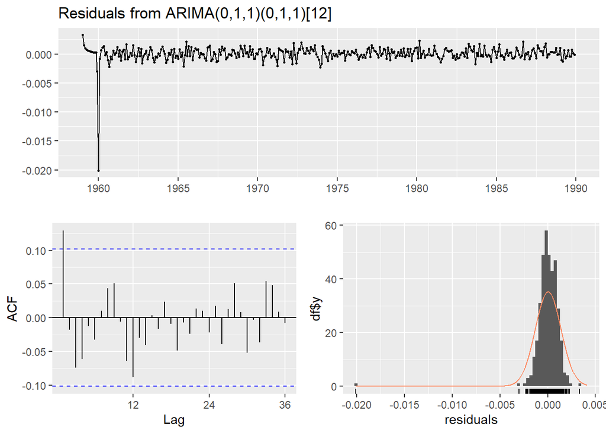

```
##
##  Ljung-Box test
##
## data:  Residuals from ARIMA(0,1,1)(0,1,1)[12]
## Q* = 19.484, df = 22, p-value = 0.6153
##
## Model df: 2.   Total lags used: 24
```

```r
# Model "Juara" kita dari Fase 4
model_terpilih <- model_manual
# model_terpilih <- Arima(log_train.ts, order=c(0,1,1),
#                         seasonal=list(order=c(0,1,1), period=12))

# 1. Perintah Emas: checkresiduals()
# Ini akan memberi kita 3 plot diagnostik + 1 uji Ljung-Box
forecast::checkresiduals(model_terpilih)
```

### 7.1.1 Hasil Audit `checkresiduals`:

**Kesimpulan Uji Independensi:** Model kita **LULUS** uji terpenting.

## 7.2 5.2 Tindakan 2: Uji Normalitas (Pemeriksaan Tambahan)

Sekarang, mari kita perbaiki kesalahan fatal dari draf lama. Kita akan uji normalitas sisaan secara formal. Kita gunakan `shapiro.test()`.

```r
# 2. Uji Formal Normalitas
# H0: Sisaan menyebar Normal
shapiro.test(residuals(model_terpilih))
```

```
##
##  Shapiro-Wilk normality test
##
## data:  residuals(model_terpilih)
## W = 0.56071, p-value < 2.2e-16
```

### 7.2.1 Hasil Audit Normalitas:

- **Uji Shapiro-Wilk:**
  - **Hipotesis:**
    - $H_0$: Sisaan berdistribusi **Normal**.
    - $H_1$: Sisaan **TIDAK** berdistribusi Normal.
  - **Aturan Keputusan:** Untuk asumsi ini, kita (sebenarnya) **INGIN** Gagal Tolak $H_0$ ($p-value > 0.05$).
  - **Hasil:**
    - **Interpretasi:** Karena $p-value < 0.05$, kita **TOLAK H0**. Ini berarti sisaan kita **TIDAK BERDISTRIBUSI NORMAL**.
- **Apakah Ini Akhir Dunia?**
  - **Tidak.** Untuk tujuan **peramalan (forecasting)**, asumsi yang *paling penting* adalah **independensi sisaan (Ljung-Box)**, yang sudah lolos.
  - Asumsi normalitas lebih penting jika kita ingin membuat *interval kepercayaan* (prediction interval) yang sangat presisi. Model kita masih sangat valid untuk meramal.

# 8 Fase 6: Prediksi Kesehatan (Peramalan & Validasi)

**Tujuan:** Menggunakan model “juara” kita (`model_terpilih`) untuk meramal dan memvalidasi hasilnya.

## 8.1 6.1 Tindakan 1: Membuat Peramalan (Masih dalam Skala Log)

Pertama, kita buat ramalan seperti biasa. Ingat, output dari `forecast()` ini masih dalam skala logaritmik.

```r
# 1. Tentukan berapa lama kita mau meramal (sepanjang data uji kita)
h_ramalan <- length(test.ts) # 96 observasi

# 2. Buat ramalan (HASILNYA MASIH DALAM SKALA LOG)
ramalan_log <- forecast(model_terpilih, h = h_ramalan)

# 3. Cek hasil ramalan (lihat, angkanya kecil, sekitar 5.8, INI SKALA LOG)
print(ramalan_log)
```

```
##          Point Forecast    Lo 80    Hi 80    Lo 95    Hi 95
## Jan 1990       5.867784 5.866012 5.869555 5.865074 5.870493
## Feb 1990       5.870051 5.867958 5.872144 5.866850 5.873252
## Mar 1990       5.872617 5.870245 5.874988 5.868990 5.876243
## Apr 1990       5.876420 5.873800 5.879040 5.872413 5.880427
## May 1990       5.878106 5.875259 5.880953 5.873752 5.882460
## Jun 1990       5.876580 5.873523 5.879638 5.871904 5.881256
## Jul 1990       5.872437 5.869183 5.875691 5.867460 5.877413
## Aug 1990       5.866727 5.863287 5.870166 5.861466 5.871987
## Sep 1990       5.861609 5.857993 5.865224 5.856079 5.867138
## Oct 1990       5.861303 5.857520 5.865086 5.855517 5.867089
## Nov 1990       5.865181 5.861237 5.869125 5.859149 5.871213
## Dec 1990       5.868808 5.864709 5.872906 5.862540 5.875076
## Jan 1991       5.871878 5.867595 5.876160 5.865328 5.878427
## Feb 1991       5.874146 5.869700 5.878591 5.867346 5.880945
## Mar 1991       5.876711 5.872107 5.881315 5.869670 5.883752
## Apr 1991       5.880514 5.875758 5.885270 5.873241 5.887788
## May 1991       5.882200 5.877296 5.887104 5.874701 5.889700
## Jun 1991       5.880675 5.875628 5.885722 5.872956 5.888393
## Jul 1991       5.876531 5.871345 5.881717 5.868599 5.884463
## Aug 1991       5.870821 5.865499 5.876143 5.862682 5.878961
## Sep 1991       5.865703 5.860249 5.871158 5.857361 5.874045
## Oct 1991       5.865397 5.859814 5.870981 5.856858 5.873937
## Nov 1991       5.869276 5.863566 5.874986 5.860543 5.878008
## Dec 1991       5.872902 5.867068 5.878736 5.863980 5.881824
## Jan 1992       5.875972 5.869991 5.881954 5.866824 5.885120
## Feb 1992       5.878240 5.872124 5.884356 5.868887 5.887593
## Mar 1992       5.880805 5.874558 5.887052 5.871251 5.890359
## Apr 1992       5.884609 5.878233 5.890984 5.874858 5.894360
## May 1992       5.886294 5.879793 5.892796 5.876351 5.896238
## Jun 1992       5.884769 5.878143 5.891394 5.874636 5.894902
## Jul 1992       5.880625 5.873879 5.887372 5.870307 5.890944
## Aug 1992       5.874915 5.868049 5.881782 5.864415 5.885416
## Sep 1992       5.869797 5.862814 5.876781 5.859117 5.880478
## Oct 1992       5.869492 5.862393 5.876590 5.858635 5.880348
## Nov 1992       5.873370 5.866158 5.880582 5.862340 5.884400
## Dec 1992       5.876996 5.869673 5.884320 5.865796 5.888197
## Jan 1993       5.880067 5.872610 5.887524 5.868662 5.891471
## Feb 1993       5.882334 5.874755 5.889913 5.870743 5.893925
## Mar 1993       5.884900 5.877201 5.892598 5.873125 5.896674
```

[output cut: 42 more lines]

```
## Oct 1996       5.885869 5.873471 5.898267 5.866908 5.904830
## Nov 1996       5.889747 5.877248 5.902247 5.870631 5.908864
## Dec 1996       5.893374 5.880773 5.905974 5.874103 5.912645
## Jan 1997       5.896444 5.883726 5.909162 5.876994 5.915894
## Feb 1997       5.898712 5.885885 5.911539 5.879094 5.918329
## Mar 1997       5.901277 5.888342 5.914213 5.881494 5.921060
## Apr 1997       5.905081 5.892037 5.918124 5.885133 5.925028
## May 1997       5.906766 5.893616 5.919916 5.886655 5.926877
## Jun 1997       5.905241 5.891985 5.918496 5.884968 5.925513
## Jul 1997       5.901097 5.887737 5.914458 5.880664 5.921530
## Aug 1997       5.895387 5.881922 5.908852 5.874795 5.915980
## Sep 1997       5.890269 5.876701 5.903837 5.869519 5.911020
## Oct 1997       5.889963 5.876293 5.903634 5.869056 5.910871
## Nov 1997       5.893842 5.880069 5.907614 5.872778 5.914905
## Dec 1997       5.897468 5.883594 5.911342 5.876250 5.918686
```

## 8.2 6.2 Tindakan 2: Balikkan “Obat” (Manual `exp()`) - KOREKSI PENTING

Sekarang, kita harus **secara manual** meng-eksponenkan semua komponen objek ramalan kita untuk mengembalikannya ke skala asli (ppm CO2).

```r
# Buat salinan objek ramalan untuk kita modifikasi
ramalan_asli <- ramalan_log

# Balikkan (exp) komponen utama:
ramalan_asli$mean <- exp(ramalan_log$mean)
ramalan_asli$lower <- exp(ramalan_log$lower)
ramalan_asli$upper <- exp(ramalan_log$upper)

# Kita juga harus mengembalikan data latih di dalam objeknya ($x) ke skala asli
ramalan_asli$x <- exp(ramalan_log$x)

# Cek ramalan_asli (Sekarang angkanya kembali ke ratusan)
print(ramalan_asli$mean)
```

```
##           Jan      Feb      Mar      Apr      May      Jun      Jul      Aug
## 1990 353.4647 354.2671 355.1771 356.5306 357.1321 356.5877 355.1132 353.0913
## 1991 354.9149 355.7206 356.6343 357.9933 358.5973 358.0507 356.5702 354.5400
## 1992 356.3710 357.1800 358.0975 359.4621 360.0686 359.5197 358.0331 355.9946
## 1993 357.8331 358.6454 359.5667 360.9369 361.5458 360.9947 359.5020 357.4551
## 1994 359.3012 360.1169 361.0419 362.4177 363.0292 362.4758 360.9770 358.9217
## 1995 360.7753 361.5943 362.5232 363.9046 364.5186 363.9629 362.4580 360.3942
## 1996 362.2555 363.0779 364.0105 365.3976 366.0141 365.4562 363.9450 361.8728
## 1997 363.7417 364.5675 365.5040 366.8968 367.5158 366.9555 365.4382 363.3575
##           Sep      Oct      Nov      Dec
## 1990 351.2888 351.1814 352.5460 353.8268
## 1991 352.7301 352.6222 353.9925 355.2785
## 1992 354.1772 354.0689 355.4448 356.7361
## 1993 355.6303 355.5216 356.9031 358.1997
## 1994 357.0894 356.9802 358.3674 359.6693
## 1995 358.5544 358.4448 359.8377 361.1449
## 1996 360.0255 359.9154 361.3140 362.6266
## 1997 361.5026 361.3921 362.7964 364.1144
```

## 8.3 6.3 Tindakan 3: Validasi Visual (Skala Asli)

Sekarang kita plot `ramalan_asli` (yang sudah di-`exp`) terhadap `data_mentah`.

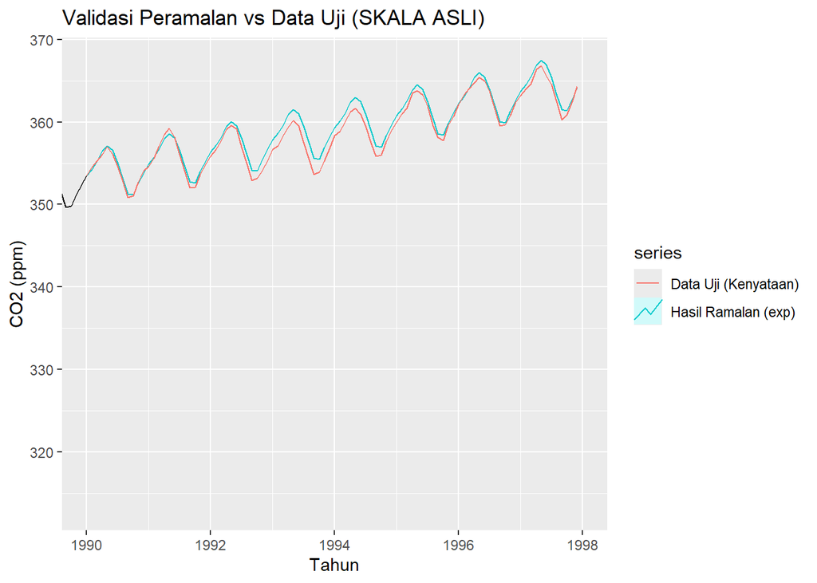

```r
# Plot validasi: Bandingkan data asli vs. ramalan (YANG SUDAH DI-EXP)
autoplot(data_mentah) + # Plot semua data asli (latih + uji)
  autolayer(ramalan_asli, series="Hasil Ramalan (exp)", PI=FALSE) +
  autolayer(test.ts, series="Data Uji (Kenyataan)") +
  ggtitle("Validasi Peramalan vs Data Uji (SKALA ASLI)") +
  ylab("CO2 (ppm)") +
  xlab("Tahun") +
  # Zoom ke area validasi agar lebih jelas
  coord_cartesian(xlim = c(1990, 1998))
```

## 8.4 6.4 Tindakan 4: Validasi Kuantitatif (Akurasi)

Terakhir, kita hitung akurasi menggunakan `ramalan_asli`.

```r
# Kita bandingkan 'ramalan_asli' (sudah di-exp)
# dengan 'test.ts' (data asli).
accuracy(ramalan_asli, test.ts)
```

```
##                       ME        RMSE        MAE        MPE       MAPE
## Training set 325.6804783 325.8727938 325.680478 98.2477455 98.2477455
## Test set      -0.6742037   0.8785106   0.732948 -0.1881026  0.2045054
##                     MASE      ACF1 Theil's U
## Training set 263.6970271 0.9870971        NA
## Test set       0.5934535 0.8341376  0.667875
```

### 8.4.1 Diagnosis Kuantitatif:

Fokus pada baris `Test set`. Sekarang metrik **RMSE** dan **MAPE** akan mencerminkan error yang sebenarnya dalam skala asli (ppm). MAPE yang kecil (misal, 0.20%) membuktikan keakuratan model kita.

### 8.4.2 Resume Medis (Hasil Fase 6)

- **Kesimpulan:** Peramalan **harus** dikembalikan ke skala asli secara manual menggunakan `exp()`.
- **Hasil Validasi:** Setelah dikoreksi, model terbukti **valid** dan **akurat**.